# Part 2 - Linear Regression

Zuliani Riccardo

17/1/2024

# 1 Load Libraries

```r
# installation of packages in case the user has not installed yet
requirements <- c("leaflet", "car", "caTools", "tidyverse")

for (req in requirements){
  if (!require(req, character.only = TRUE)){
      install.packages(req)
  }
}
```

# 2 Linear Regression

First things first load the cleaned train and test datasets.

```r
fire_data_clean.train <- read.csv("datasets/fire_data_clean.train.csv",
                                  stringsAsFactors = TRUE)
fire_data_clean.test <- read.csv("datasets/fire_data_clean.test.csv",
                                 stringsAsFactors = TRUE)

fire_data_clean.train$cong_dist <- as.factor(fire_data_clean.train$cong_dist)
fire_data_clean.test$cong_dist <- as.factor(fire_data_clean.test$cong_dist)
```

## 2.1 Use inc_resp_min_qy as response

```r
# load train and test datasets
resp_min_fd.train <- fire_data_clean.train
resp_min_fd.test <- fire_data_clean.test

# remove the future time differences
resp_min_fd.train <- resp_min_fd.train %>% select(-c(emergency_min_qy))
resp_min_fd.test <- resp_min_fd.test %>% select(-c(emergency_min_qy))
```

Let’s build our first Linear Regression Model.

```r
res_lm.full <- lm(inc_resp_min_qy ~ ., data = resp_min_fd.train)
summary(res_lm.full)
```

```
##
## Call:
## lm(formula = inc_resp_min_qy ~ ., data = resp_min_fd.train)
##
## Residuals:
##    Min     1Q Median     3Q    Max
## -7.579 -1.362 -0.387  0.797 52.096
##
## Coefficients:
##                                 Estimate Std. Error t value Pr(>|t|)
## (Intercept)                     6.432566   0.238999  26.915  < 2e-16 ***
## inc_boroughBrooklyn            -0.777498   0.111424  -6.978 3.07e-12 ***
## inc_boroughManhattan           -0.317584   0.096424  -3.294 0.000990 ***
## inc_boroughQueens               0.017795   0.103635   0.172 0.863665
## inc_boroughStaten Island       -0.686276   0.180180  -3.809 0.000140 ***
## cong_dist5                     -0.526126   0.143579  -3.664 0.000248 ***
## cong_dist6                     -0.136570   0.150617  -0.907 0.364558
## cong_dist7                     -0.297748   0.154653  -1.925 0.054207 .
## cong_dist8                     -0.074574   0.170482  -0.437 0.661803
## cong_dist9                     -0.064911   0.173211  -0.375 0.707848
## cong_dist10                    -0.211573   0.169415  -1.249 0.211733
## cong_dist11                     0.019877   0.203041   0.098 0.922014
## cong_dist12                     0.769480   0.180132   4.272 1.95e-05 ***
## cong_dist13                     0.034462   0.172636   0.200 0.841776
## cong_dist14                     0.363853   0.159679   2.279 0.022697 *
## cong_dist15                     0.001747   0.173684   0.010 0.991972
## cong_dist16                     0.189488   0.241924   0.783 0.433485
## al_source_descEMS              -0.193955   0.114045  -1.701 0.089015 .
## al_source_descEMS-911          -0.224393   0.114963  -1.952 0.050966 .
## al_source_descOthers           -1.048011   0.117633  -8.909  < 2e-16 ***
## al_source_descPHONE            -0.009961   0.054614  -0.182 0.855281
## al_index_descInitial Alarm     -0.209377   0.071230  -2.939 0.003291 **
## al_index_descOthers             1.033326   0.775457   1.333 0.182696
## highest_al_levelNonFirst Alarm -0.273546   0.787056  -0.348 0.728177
## inc_class_groupM_MFAs          -0.298057   0.245141  -1.216 0.224051
## inc_class_groupNonM_E           0.463379   0.105871   4.377 1.21e-05 ***
## inc_class_groupNonM_MFAs        0.272255   0.154816   1.759 0.078662 .
## inc_class_groupNonS_F          -0.206078   0.162329  -1.270 0.204273
## inc_class_groupS_F             -0.051989   0.135047  -0.385 0.700264
## engines_assigned               -0.480012   0.027444 -17.491  < 2e-16 ***
## ladders_assigned                0.185240   0.043240   4.284 1.84e-05 ***
## others_units_assigned          -0.082868   0.027276  -3.038 0.002383 **
## day_typeWeekend                -0.183876   0.036559  -5.030 4.95e-07 ***
## working_hourTRUE               -0.263551   0.098290  -2.681 0.007337 **
## time_of_dayEvening             -0.569366   0.107453  -5.299 1.18e-07 ***
## time_of_dayMorning              0.141329   0.043096   3.279 0.001042 **
## time_of_dayNight                0.132103   0.110688   1.193 0.232695
## tua_is_oneTRUE                  1.083569   0.059964  18.070  < 2e-16 ***
## ---
## Signif. codes:  0 '***' 0.001 '**' 0.01 '*' 0.05 '.' 0.1 ' ' 1
##
## Residual standard error: 2.543 on 24542 degrees of freedom
## Multiple R-squared:  0.1283, Adjusted R-squared:  0.127
## F-statistic: 97.63 on 37 and 24542 DF,  p-value: < 2.2e-16
```

By the summary we can see that the model $R^2$ tells us that we are able to explain around the $12.83\%$ percent of the total variability of the data and also the Adjusted R-squared which penalises the complexity of our model tells us the same story.

So the intercept explain the mean response time in minutes for an incident with the cited values of categorical predictors and the value of the three following numeric predictors:

- engines_assiged = 0
- ladders_assigned = 0
- others_units_assigned = 0

At this point we can analyse the **regression diagnostic plots**:

Now We recall that linear regression makes several assumptions about the data, such as :

1. **Linearity of the data:** the relationship between the predictor (x) and the outcome (y) is assumed to be linear.
2. **Normality of residuals:** the residual errors are assumed to be normally distributed.
3. **Homogeneity of residuals variance:** the residuals are assumed to have a constant variance (homoscedasticity)
4. **Independence of residuals error terms**

We should check whether or not these assumptions hold true. Potential problems include:

- *Non-linearity* of the outcome - predictor relationships
- *Heteroscedasticity* Non-constant variance of error terms.
- *Presence of influential values* in the data that can be:
  - Outliers: extreme values in the outcome (y) variable
  - High-leverage points: extreme values in the predictors (x) variable

All these assumptions and potential problems can be checked by producing some **diagnostic plots** visualizing the residual errors.

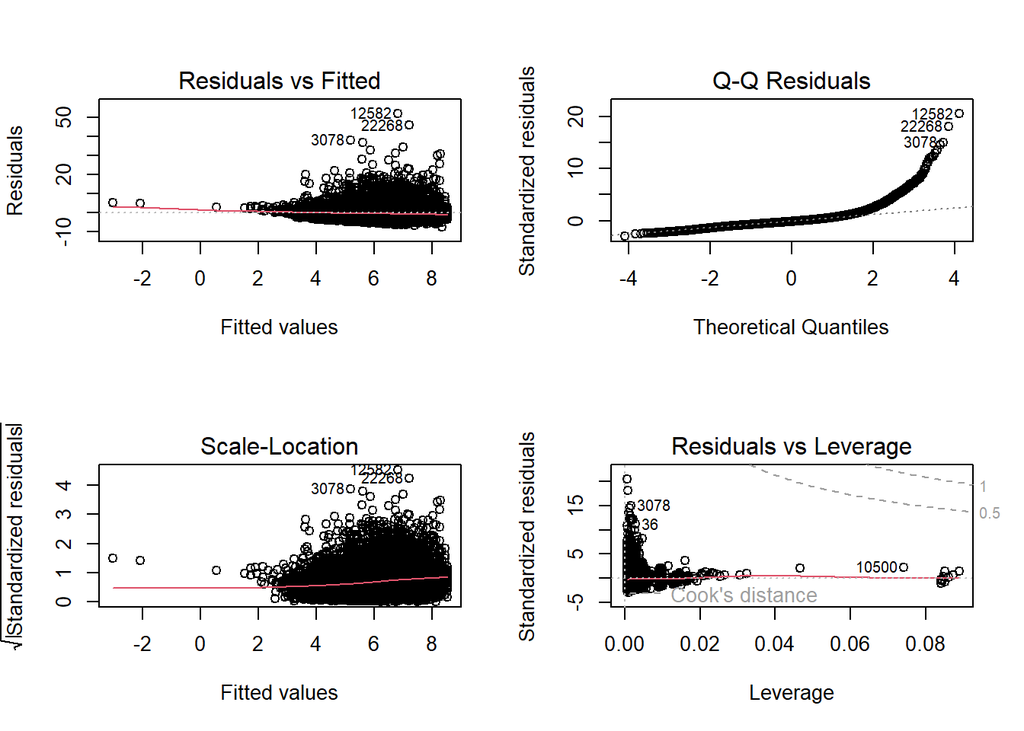

```r
par(mfrow=c(2,2))
plot(res_lm.full)
```

1. **Residuals vs Fitted Plot**: Used to check the linear relationship assumptions, this is proved by the straight horizontal red line at zero level, like our case. Even if, we have a higher amount of spreaded observations on the top right of the red line.
2. **Q-Q Residuals Plot**: in this plot also called quantile - quantile residual plot and tells us if the residuals are normally distributed or not. If they follow the dotted red line we can say so otherwise as in our case we can’t say that they are normally distributed, as we will see in much detail later.
3. **Scaled-Location / Spread-Location plot**: tells us if the residuals are equally spread across the predictors. This is the assessment of Homoscedasticity or equal variance. And we would like to see a sort of horizontal line, in our case we are no much satisfied since we have again many observation on top the red line and there is a litte curvature.
4. **Residuals VS Leverage plot**: helps us to identify the outliers and high leverage points with the Cook’s distance, so points that have influence on the regression line. In this plot we look for data points outside of a dashed line, Cook’s distance. When the points are outside of the Cook’s distance, this means that they have high Cook’s distance scores. In our case we do not have any observations that satisfy what we have just said.

Moreover we better analyse the distribution of the residuals by using the `qqPlot` from the `car` package. This will produce a better plot of the distribution of the residuals with relative confidence interval ban in blue.

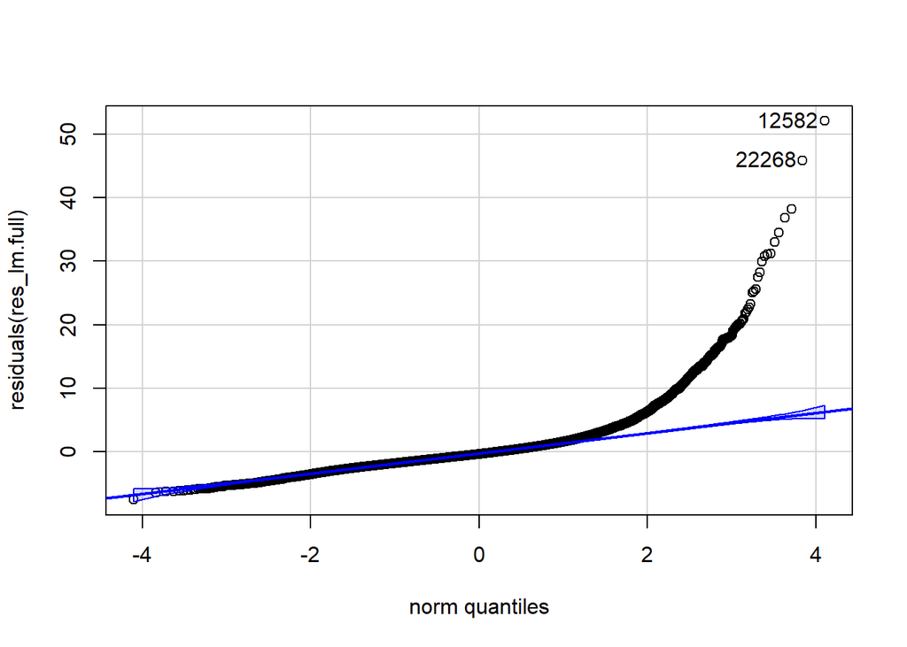

```
## [1] 12582 22268
```

```r
qqPlot(residuals(res_lm.full))
```

Much clearly the qqPlot tells that the data the residuals are not normally distributed indeed are heavily right skewed. Thus we can’t trust the p-values and the estimation of the coefficients.

For curiosity we analyse in a better and much detailed plot the presence of influential points.

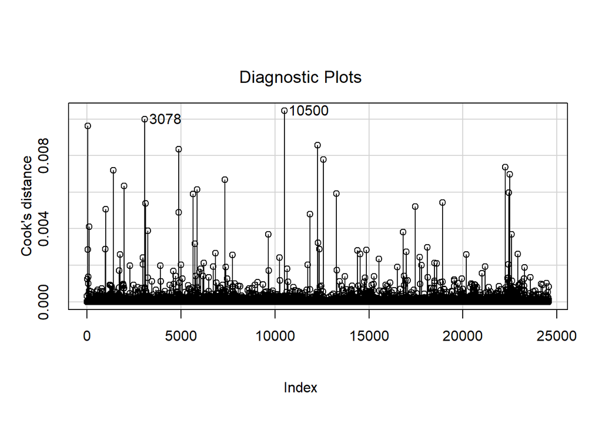

```r
influenceIndexPlot(res_lm.full, vars = "Cook")
```

And as we can see thre are no points considered as influential.

Here instead we have a look at all plots of residuals vs predictors and again the plot of residuals vs fitted values that we already see.

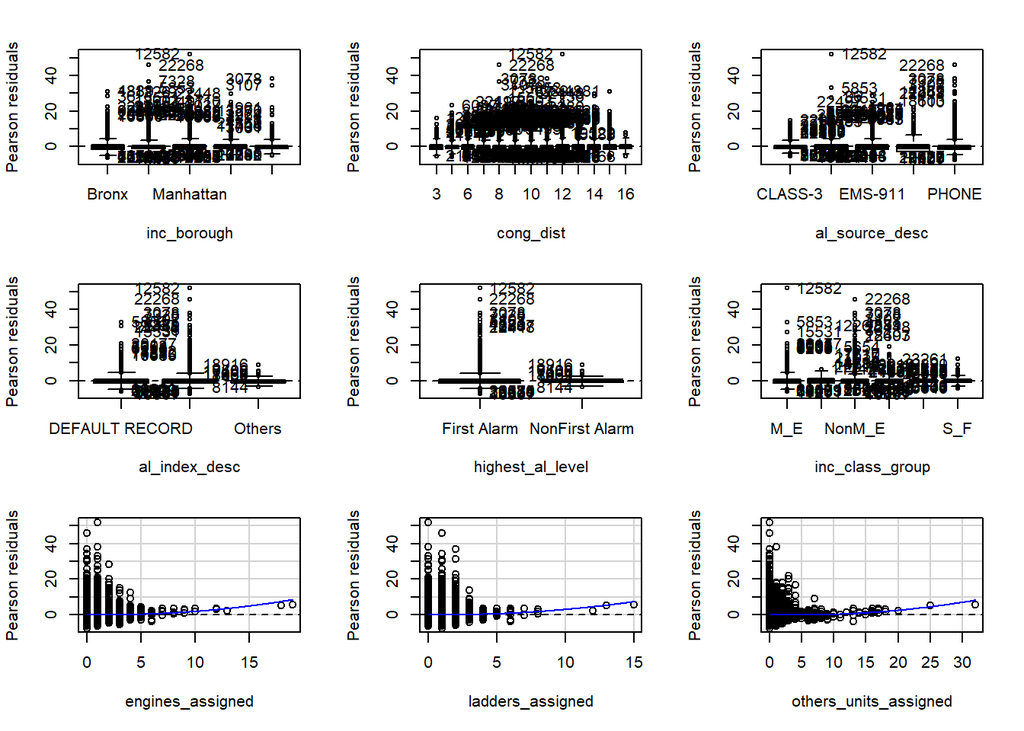

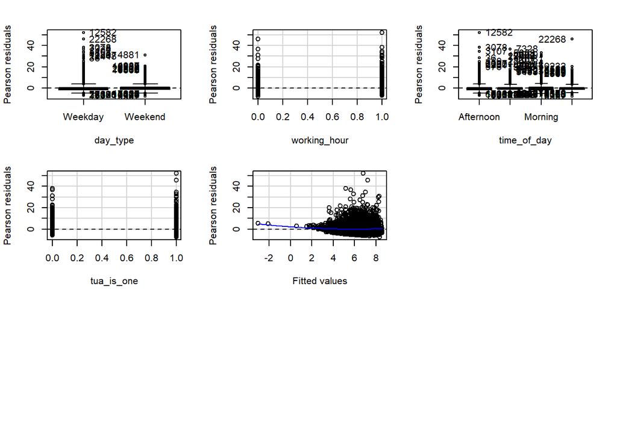

```
##                       Test stat Pr(>|Test stat|)
## inc_borough
## cong_dist
## al_source_desc
## al_index_desc
## highest_al_level
## inc_class_group
## engines_assigned         7.3922        1.491e-13 ***
## ladders_assigned         6.4210        1.379e-10 ***
## others_units_assigned    5.8162        6.093e-09 ***
## day_type
## working_hour             0.9476           0.3433
## time_of_day
## tua_is_one              -0.5172           0.6050
## Tukey test               7.1290        1.011e-12 ***
## ---
## Signif. codes:  0 '***' 0.001 '**' 0.01 '*' 0.05 '.' 0.1 ' ' 1
```

```r
residualPlots(res_lm.full)
```

Let’s have a look at the possible power transformation of the response.

```r
powerTransform(res_lm.full)
```

```
## Estimated transformation parameter
##        Y1
## 0.0918338
```

The function **powerTransform** suggests taking the log-transformation of the response, we take the log transformation because the estimated value of **lambda** is close to zero.

But before updating the full model scaling the response by the logarithm, let’s check if we have **multicollinearity**. To do so we use the `vif` function by the `car` package.

```r
vif(res_lm.full)
```

```
##                             GVIF Df GVIF^(1/(2*Df))
## inc_borough           296.746107  4        2.037268
## cong_dist             306.824565 12        1.269464
## al_source_desc         13.194620  4        1.380542
## al_index_desc          14.751137  2        1.959776
## highest_al_level        8.021463  1        2.832219
## inc_class_group        19.943038  5        1.348898
## engines_assigned        2.611920  1        1.616144
## ladders_assigned        4.764514  1        2.182777
## others_units_assigned   2.371379  1        1.539928
## day_type                1.005439  1        1.002716
## working_hour            8.902130  1        2.983644
## time_of_day             8.994580  3        1.442105
## tua_is_one              3.335387  1        1.826304
```

We decide to use as a rule of thumb $GIF < 10$ no **strong multicollinearity** problem. Multicollinearity means that one predictor variable can be predicted by a linear combination of others predictors. This problem could cause the coefficient to be unstable and unreliable, moreover the standard errors of the regression coefficients tend to increase in the presence of multicollinearity. And higher standard errors mean wider confidence intervals and reduced precision in estimating the true values of the coefficients.

In our case we decide to remove the following predictors:

- cong_dist
- inc_class_group
- highest_al_level

Let’s update our model scaling the response to the logarithm scale and remove the previously listed predictors.

```r
res_lm.full.upd <- update(res_lm.full, log(inc_resp_min_qy) ~ . - cong_dist - inc_class_group - highest_al_level)
vif(res_lm.full.upd)
```

```
##                           GVIF Df GVIF^(1/(2*Df))
## inc_borough           1.036957  4        1.004547
## al_source_desc        3.850387  4        1.183554
## al_index_desc         1.654411  2        1.134125
## engines_assigned      2.340625  1        1.529910
## ladders_assigned      4.461953  1        2.112334
## others_units_assigned 2.344313  1        1.531115
## day_type              1.004243  1        1.002119
## working_hour          8.895229  1        2.982487
## time_of_day           8.958791  3        1.441147
## tua_is_one            3.230816  1        1.797447
```

No multicollinearity problem, now we can analyse the summary of the updated model.

```r
summary(res_lm.full.upd)
```

```
##
## Call:
## lm(formula = log(inc_resp_min_qy) ~ inc_borough + al_source_desc +
##     al_index_desc + engines_assigned + ladders_assigned + others_units_assigned +
##     day_type + working_hour + time_of_day + tua_is_one, data = resp_min_fd.train)
##
## Residuals:
##      Min       1Q   Median       3Q      Max
## -2.47299 -0.20076 -0.00435  0.19997  2.31625
##
## Coefficients:
##                              Estimate Std. Error t value Pr(>|t|)
## (Intercept)                 1.9203530  0.0199673  96.175  < 2e-16 ***
## inc_boroughBrooklyn        -0.1773411  0.0068022 -26.071  < 2e-16 ***
## inc_boroughManhattan       -0.0365833  0.0071839  -5.092 3.56e-07 ***
## inc_boroughQueens          -0.0485684  0.0074903  -6.484 9.09e-11 ***
## inc_boroughStaten Island   -0.1271892  0.0119259 -10.665  < 2e-16 ***
## al_source_descEMS          -0.1012257  0.0109365  -9.256  < 2e-16 ***
## al_source_descEMS-911      -0.1069802  0.0115198  -9.287  < 2e-16 ***
## al_source_descOthers       -0.4644379  0.0171267 -27.118  < 2e-16 ***
## al_source_descPHONE        -0.0314929  0.0078552  -4.009 6.11e-05 ***
## al_index_descInitial Alarm -0.0170164  0.0083054  -2.049 0.040490 *
## al_index_descOthers        -0.0003746  0.0483631  -0.008 0.993819
## engines_assigned           -0.0860849  0.0038124 -22.580  < 2e-16 ***
## ladders_assigned            0.0220199  0.0061406   3.586 0.000336 ***
## others_units_assigned      -0.0045723  0.0039798  -1.149 0.250620
## day_typeWeekend            -0.0201366  0.0053617  -3.756 0.000173 ***
## working_hourTRUE           -0.0690787  0.0144184  -4.791 1.67e-06 ***
## time_of_dayEvening         -0.1084972  0.0157624  -6.883 5.99e-12 ***
## time_of_dayMorning          0.0143992  0.0063203   2.278 0.022721 *
## time_of_dayNight            0.0235714  0.0162331   1.452 0.146497
## tua_is_oneTRUE              0.1495102  0.0086606  17.263  < 2e-16 ***
## ---
## Signif. codes:  0 '***' 0.001 '**' 0.01 '*' 0.05 '.' 0.1 ' ' 1
##
## Residual standard error: 0.3731 on 24560 degrees of freedom
## Multiple R-squared:  0.1539, Adjusted R-squared:  0.1532
## F-statistic: 235.1 on 19 and 24560 DF,  p-value: < 2.2e-16
```

Now remember that we can’t compare the $R^2$ with the previous model since in the last one the response is on a different scale.

Regarding the reference level here the discussion is the same as the previous one, except the fact that the reference level is on logarithm scale so the predictors have an increasing or decreasing effect on the mean logarithm response time.

Now we analyse the **regression diagnostic plots** for the log response model.

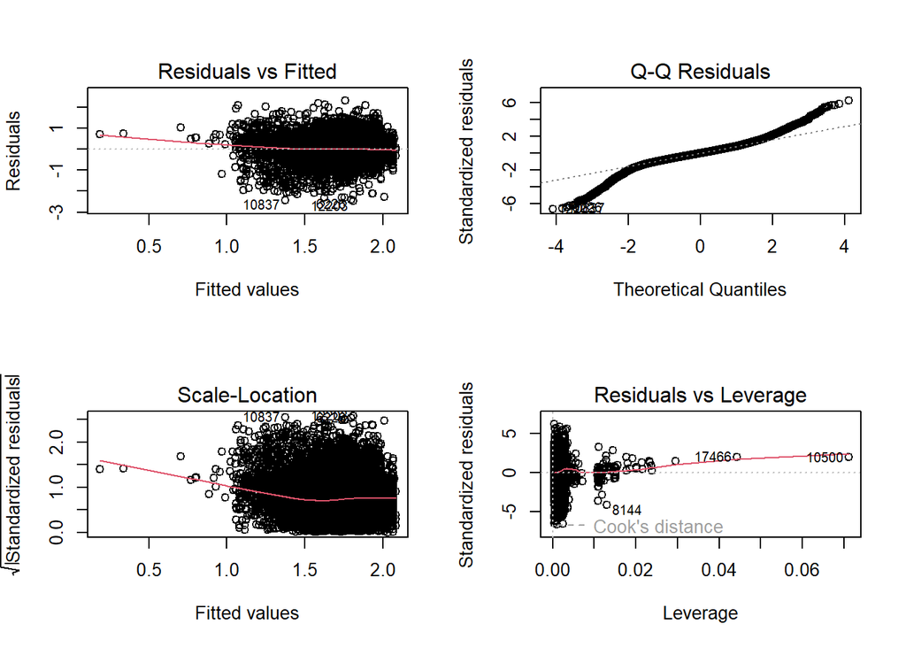

```r
par(mfrow=c(2,2))
plot(res_lm.full.upd)
```

Let’s clearly analyse the new qqPlot.

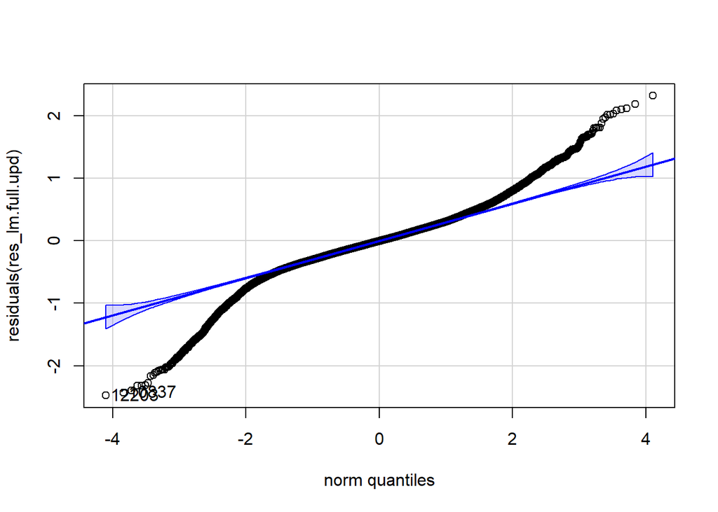

```
## [1] 12203 10837
```

```r
qqPlot(residuals(res_lm.full.upd))
```

So in other words this “S” shaped qqPlot with a linear portion in the middle suggests the data have more extreme values (or outliers) than the normal distribution in the tails. This indicate the following statements:

1. The coefficient estimates are unbiased and consistent.
2. The Standard Error could be wrong.
3. The p-values are usually much lower with respect to the real p-value. This means that a p-value in the order of 0.0001 could not be really significant.

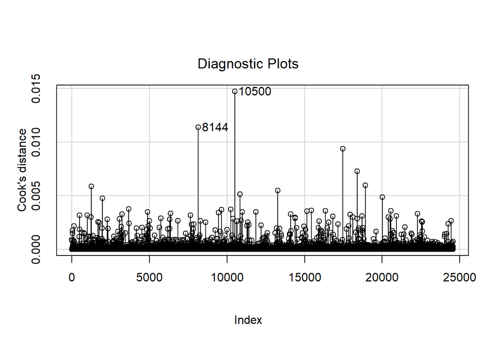

```r
influenceIndexPlot(res_lm.full.upd, vars = "Cook")
```

Again no influential points detected.

Now we can see the residuals vs predictors and residuals vs fitted values.

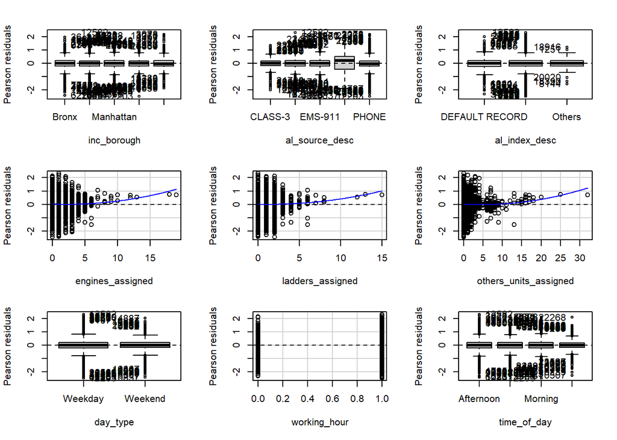

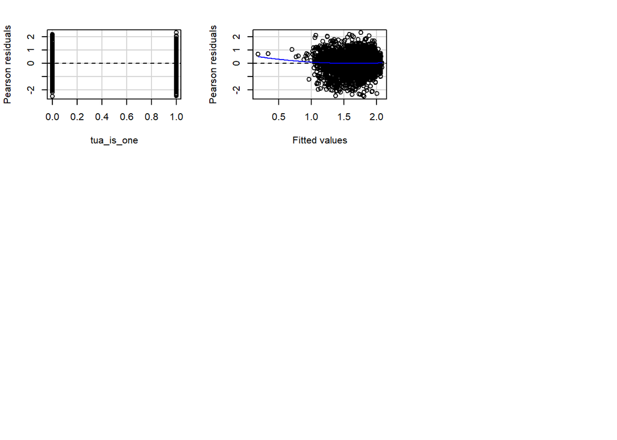

```
##                       Test stat Pr(>|Test stat|)
## inc_borough
## al_source_desc
## al_index_desc
## engines_assigned         6.7460        1.553e-11 ***
## ladders_assigned         5.9483        2.746e-09 ***
## others_units_assigned    5.9928        2.091e-09 ***
## day_type
## working_hour             0.1865           0.8521
## time_of_day
## tua_is_one               0.3149           0.7528
## Tukey test               6.3188        2.636e-10 ***
## ---
## Signif. codes:  0 '***' 0.001 '**' 0.01 '*' 0.05 '.' 0.1 ' ' 1
```

```r
residualPlots(res_lm.full.upd)
```

Thus again the linear assumptions are not met, mainly by the non normal distribution of the residuals.

At this point we have decided in any case to investigate this behaviour. So we try to fix the non-normality of the residuals by modifying the scale of some predictors.

The edits we will perform are the following one:

```r
res_lm.full.upd.2 <- update(res_lm.full.upd, . ~ . - others_units_assigned -
                              engines_assigned - ladders_assigned +
                              log(engines_assigned + 1) +
                              log(ladders_assigned + 1) +
                              log(others_units_assigned + 1) +
                              log(engines_assigned + 1))
summary(res_lm.full.upd.2)
```

```
##
## Call:
## lm(formula = log(inc_resp_min_qy) ~ inc_borough + al_source_desc +
##     al_index_desc + day_type + working_hour + time_of_day + tua_is_one +
##     log(engines_assigned + 1) + log(ladders_assigned + 1) + log(others_units_assigned +
##     1), data = resp_min_fd.train)
##
## Residuals:
##      Min       1Q   Median       3Q      Max
## -2.51334 -0.20152 -0.00374  0.20014  2.31666
##
## Coefficients:
##                                 Estimate Std. Error t value Pr(>|t|)
## (Intercept)                     2.032175   0.021628  93.961  < 2e-16 ***
## inc_boroughBrooklyn            -0.177803   0.006790 -26.185  < 2e-16 ***
## inc_boroughManhattan           -0.036462   0.007168  -5.087 3.67e-07 ***
## inc_boroughQueens              -0.049448   0.007482  -6.609 3.95e-11 ***
## inc_boroughStaten Island       -0.129561   0.011906 -10.882  < 2e-16 ***
## al_source_descEMS              -0.093353   0.011331  -8.239  < 2e-16 ***
## al_source_descEMS-911          -0.099277   0.011872  -8.362  < 2e-16 ***
## al_source_descOthers           -0.458249   0.017078 -26.833  < 2e-16 ***
## al_source_descPHONE            -0.028023   0.007847  -3.571 0.000356 ***
## al_index_descInitial Alarm     -0.016612   0.008287  -2.005 0.045017 *
## al_index_descOthers            -0.016943   0.041840  -0.405 0.685530
## day_typeWeekend                -0.020052   0.005350  -3.748 0.000179 ***
## working_hourTRUE               -0.070061   0.014387  -4.870 1.12e-06 ***
## time_of_dayEvening             -0.109069   0.015728  -6.935 4.17e-12 ***
## time_of_dayMorning              0.014572   0.006307   2.310 0.020874 *
## time_of_dayNight                0.022317   0.016197   1.378 0.168274
## tua_is_oneTRUE                  0.078191   0.010123   7.724 1.17e-14 ***
## log(engines_assigned + 1)      -0.193912   0.008353 -23.215  < 2e-16 ***
## log(ladders_assigned + 1)      -0.026963   0.011289  -2.388 0.016931 *
## log(others_units_assigned + 1) -0.057145   0.009286  -6.154 7.67e-10 ***
## ---
## Signif. codes:  0 '***' 0.001 '**' 0.01 '*' 0.05 '.' 0.1 ' ' 1
##
## Residual standard error: 0.3723 on 24560 degrees of freedom
## Multiple R-squared:  0.1576, Adjusted R-squared:  0.1569
## F-statistic: 241.8 on 19 and 24560 DF,  p-value: < 2.2e-16
```

Now we can compare this $R^2 = 0.1576$ with the one of the previous model which is $R^2 = 0.1539$. So with the newest model we have explained $0.37\%$ much variability with respect to the initial model. Pretty poor result I would say, so the effort of changing the scale of the assigned units does not pay off. We have already tried to insert some kind of interaction terms, however the model $R^2$ results in a lower value with respect to the initial one thus we prefer the cleaned model after the multicollinearity check.

So the intercept explain the mean logarithm response time for an incident with the cited values of categorical predictors and the value of the three following numeric predictors:

- log(engines_assigned + 1) = 0
- log(others_units_assigned + 1) = 0
- log(ladders_assigned + 1) = 0

Now we analyse the **regression diagnostic plots**.

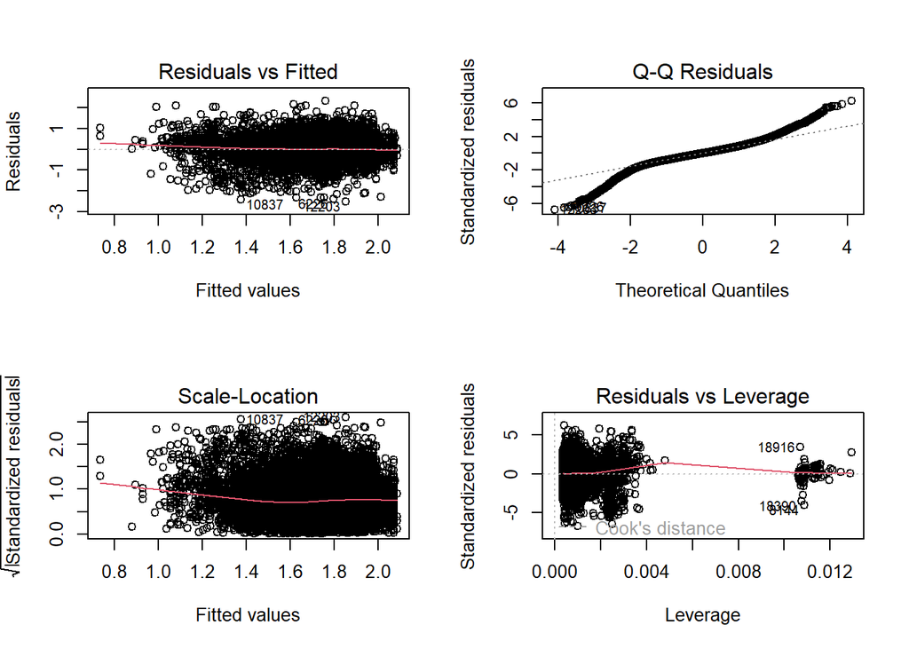

```r
par(mfrow=c(2,2))
plot(res_lm.full.upd.2)
```

1. **Residuals vs Fitted plot**: here we can see that the residuals have a linear pattern, and the residuals seem pretty much randomly spreaded.
2. **Q-Q Residuals plot**: again we do not have the situation of normal distribution of the residuals, as we will have a closer look soon.
3. **Scaled-Location / Spread-Location plot**: homoscedasticity is quite reached even if we have a light curvature.
4. **Residuals VS Leverage plot**: we can’t see any outliers and high leverage points.

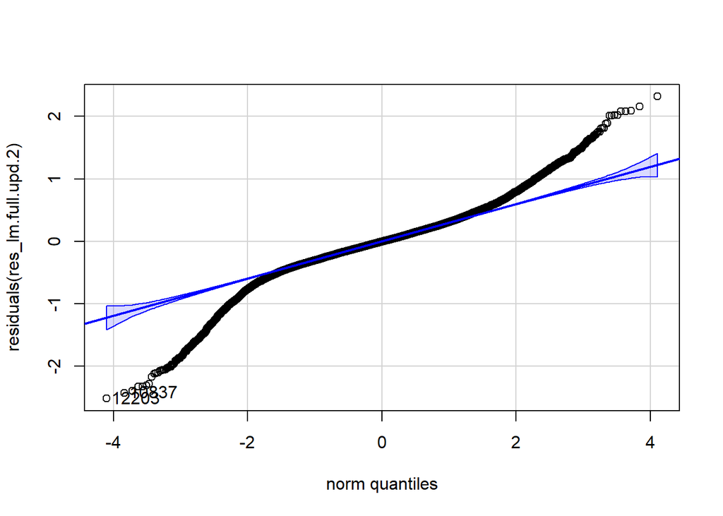

```
## [1] 12203 10837
```

```r
qqPlot(residuals(res_lm.full.upd.2))
```

Unfortunately the situation is the same as the previous described one.

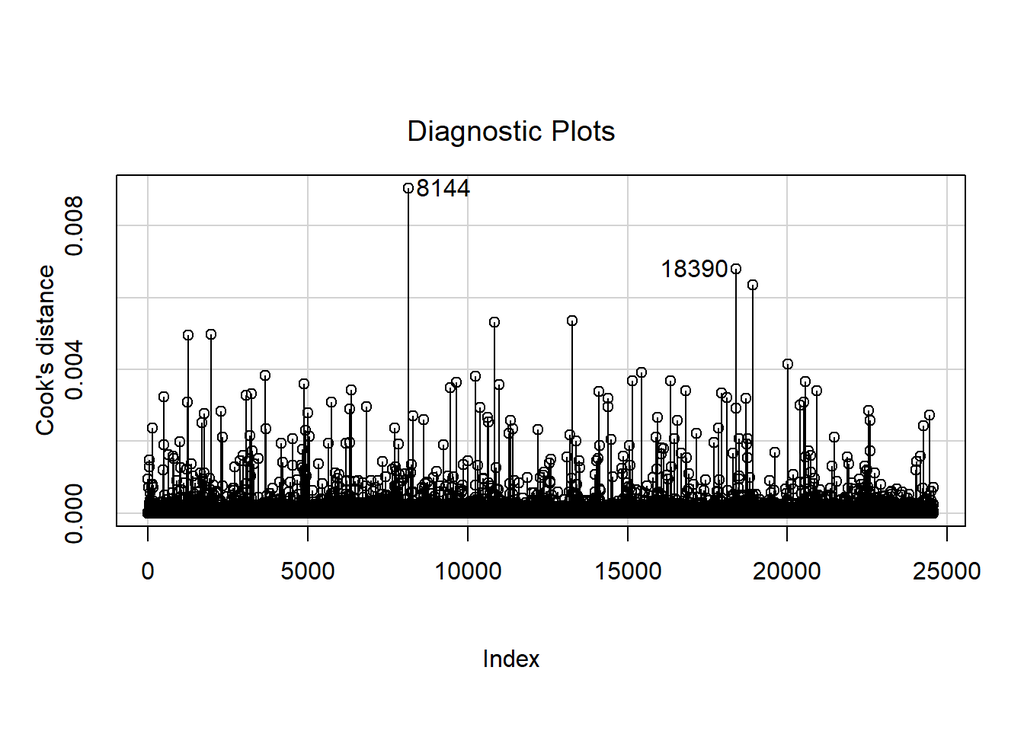

```r
influenceIndexPlot(res_lm.full.upd.2, vars = "Cook")
```

Again no influential points detected.

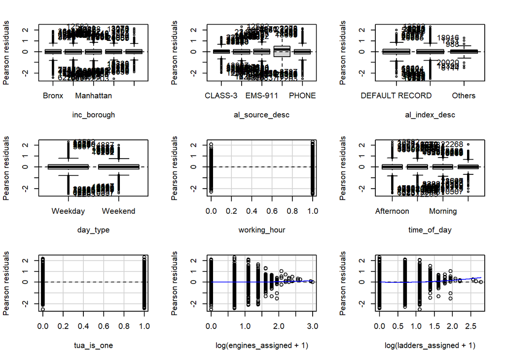

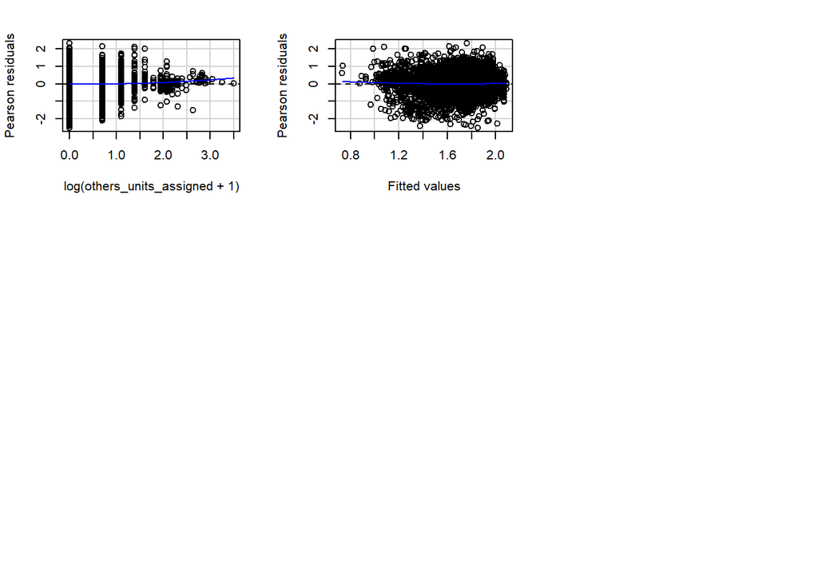

```
##                                Test stat Pr(>|Test stat|)
## inc_borough
## al_source_desc
## al_index_desc
## day_type
## working_hour                      0.2725           0.7852
## time_of_day
## tua_is_one                        0.8669           0.3860
## log(engines_assigned + 1)         4.6314        3.650e-06 ***
## log(ladders_assigned + 1)        10.3532        < 2.2e-16 ***
## log(others_units_assigned + 1)    5.6596        1.534e-08 ***
## Tukey test                        3.9529        7.722e-05 ***
## ---
## Signif. codes:  0 '***' 0.001 '**' 0.01 '*' 0.05 '.' 0.1 ' ' 1
```

```r
residualPlots(res_lm.full.upd.2)
```

In conclusion unfortunately we can’t apply linear regression on the log scale of `inc_resp_min_qy`, the main problem is the distribution of the residuals with is not normal thus we can’t really trust the p-values end the estimation of the model coefficients.

Let’s see if in the other type response the assumptions of linearity are met or not (spoiler…they are not verified again :( ).

## 2.2 Use emergency_min_qy as response

Fit a linear regression model with all the predictors.

```r
eme_lm.full <- lm(emergency_min_qy ~ ., data = fire_data_clean.train)
summary(eme_lm.full)
```

```
##
## Call:
## lm(formula = emergency_min_qy ~ ., data = fire_data_clean.train)
##
## Residuals:
##     Min      1Q  Median      3Q     Max
## -117.66   -8.59   -3.09    3.95  429.84
##
## Coefficients:
##                                Estimate Std. Error t value Pr(>|t|)
## (Intercept)                    -1.56644    1.54123  -1.016 0.309470
## inc_boroughBrooklyn            -5.72702    0.70887  -8.079 6.82e-16 ***
## inc_boroughManhattan           -0.85206    0.61297  -1.390 0.164523
## inc_boroughQueens              -3.05730    0.65866  -4.642 3.47e-06 ***
## inc_boroughStaten Island       -4.41859    1.14549  -3.857 0.000115 ***
## cong_dist5                      0.75546    0.91278   0.828 0.407875
## cong_dist6                      2.70597    0.95728   2.827 0.004706 **
## cong_dist7                      1.27991    0.98298   1.302 0.192905
## cong_dist8                      2.31850    1.08352   2.140 0.032382 *
## cong_dist9                      1.30084    1.10086   1.182 0.237354
## cong_dist10                     1.54859    1.07677   1.438 0.150395
## cong_dist11                     0.76077    1.29044   0.590 0.555506
## cong_dist12                     2.39445    1.14527   2.091 0.036563 *
## cong_dist13                     4.64611    1.09720   4.235 2.30e-05 ***
## cong_dist14                     2.67685    1.01496   2.637 0.008360 **
## cong_dist15                     3.21466    1.10386   2.912 0.003592 **
## cong_dist16                     2.22881    1.53759   1.450 0.147198
## al_source_descEMS               5.44808    0.72487   7.516 5.84e-14 ***
## al_source_descEMS-911           6.51758    0.73072   8.919  < 2e-16 ***
## al_source_descOthers            6.72007    0.74884   8.974  < 2e-16 ***
## al_source_descPHONE             3.86922    0.34710  11.147  < 2e-16 ***
## al_index_descInitial Alarm     16.02968    0.45279  35.402  < 2e-16 ***
## al_index_descOthers            64.18114    4.92866  13.022  < 2e-16 ***
## highest_al_levelNonFirst Alarm 60.26687    5.00222  12.048  < 2e-16 ***
## inc_class_groupM_MFAs          -1.89320    1.55806  -1.215 0.224341
## inc_class_groupNonM_E          -7.42976    0.67313 -11.038  < 2e-16 ***
## inc_class_groupNonM_MFAs       -3.12835    0.98401  -3.179 0.001479 **
## inc_class_groupNonS_F           2.57761    1.03173   2.498 0.012484 *
## inc_class_groupS_F             -6.30824    0.85831  -7.350 2.05e-13 ***
## inc_resp_min_qy                 0.12082    0.04057   2.978 0.002904 **
## engines_assigned                1.25752    0.17550   7.165 7.99e-13 ***
## ladders_assigned                1.42824    0.27492   5.195 2.06e-07 ***
## others_units_assigned           4.20284    0.17339  24.240  < 2e-16 ***
## day_typeWeekend                -0.24967    0.23247  -1.074 0.282837
## working_hourTRUE               -0.76343    0.62478  -1.222 0.221754
## time_of_dayEvening             -2.27278    0.68332  -3.326 0.000882 ***
## time_of_dayMorning              0.55943    0.27396   2.042 0.041161 *
## time_of_dayNight               -1.54255    0.70350  -2.193 0.028341 *
## tua_is_oneTRUE                  1.40265    0.38363   3.656 0.000256 ***
## ---
## Signif. codes:  0 '***' 0.001 '**' 0.01 '*' 0.05 '.' 0.1 ' ' 1
##
## Residual standard error: 16.16 on 24541 degrees of freedom
## Multiple R-squared:  0.3359, Adjusted R-squared:  0.3349
## F-statistic: 326.7 on 38 and 24541 DF,  p-value: < 2.2e-16
```

The first thing that comes to our eyes is the $R^2$ value which in this case is $0.3359$ thus we explain more or less 1/3 of the variability of the data. Also the Adjusted R-squared has a similar value which is $0.3349$.

- engines_assiged = 0
- ladders_assigned = 0
- others_units_assigned = 0
- inc_resp_min_qy = 0

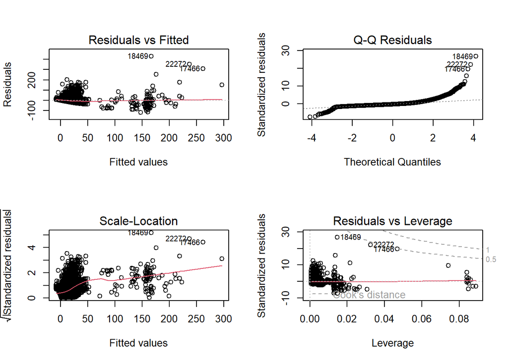

```r
par(mfrow=c(2,2))
plot(eme_lm.full)
```

1. **Residuals vs Fitted plot**: Here the fitted values vs the residual are behaving in a linear relation but they are not randomly spread since again we can view three or even more clusters.
2. **Q-Q Residuals plot**: again we do not have the situation of normal distribution of the residuals, as we will have a closer look soon.
3. **Scaled-Location / Spread-Location plot**: homoscedasticity is not verified since we do not have constant variance of the residuals, in fact we can see a big cluster on the left and small groups of observation spreaded in the rest of the plot.
4. **Residuals VS Leverage plot**: we can see two points that are close to be influential and high leverage, later we have a closer look on those two.

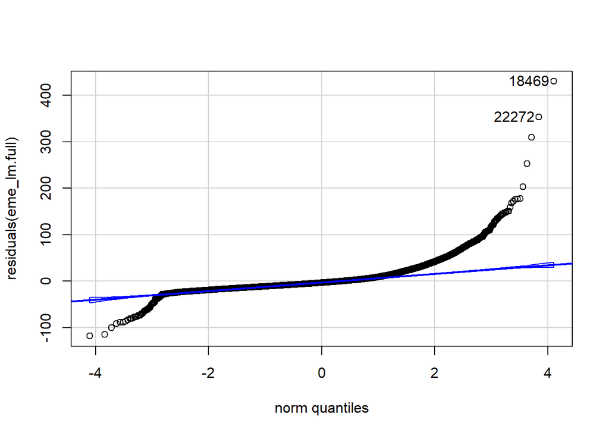

```
## [1] 18469 22272
```

```r
qqPlot(residuals(eme_lm.full))
```

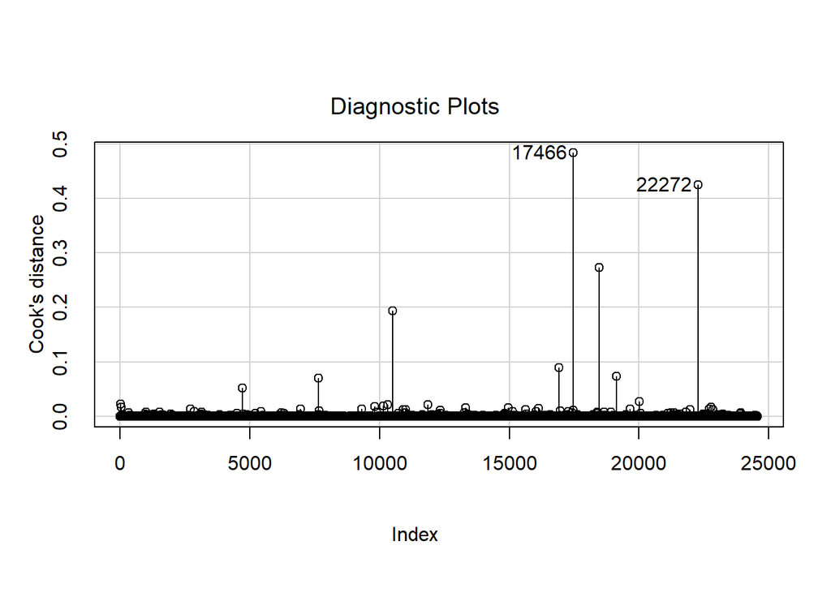

```r
influenceIndexPlot(eme_lm.full, vars = "Cook")
```

As previously said, we have two points that are almost influential.

Now we have a look at the possible power transformation of the response.

```r
powerTransform(eme_lm.full)
```

```
## Estimated transformation parameter
##        Y1
## 0.1396974
```

We will try to transform the response both using the **logarithm scale** and the **power of 0.14**. in order to see if we have an improvement on the distribution of the residuals.

But before updating the full model, scaling the response by logarithm, let’s check if we have **multicollinearity**. To do so we use the `vif` function by the `car` package.

```r
vif(eme_lm.full)
```

```
##                             GVIF Df GVIF^(1/(2*Df))
## inc_borough           297.733490  4        2.038114
## cong_dist             309.983817 12        1.270006
## al_source_desc         13.241310  4        1.381152
## al_index_desc          14.757897  2        1.960000
## highest_al_level        8.021502  1        2.832226
## inc_class_group        20.007948  5        1.349336
## inc_resp_min_qy         1.147185  1        1.071067
## engines_assigned        2.644479  1        1.626186
## ladders_assigned        4.768077  1        2.183593
## others_units_assigned   2.372271  1        1.540218
## day_type                1.006475  1        1.003232
## working_hour            8.904738  1        2.984081
## time_of_day             9.067792  3        1.444055
## tua_is_one              3.379765  1        1.838414
```

### 2.2.1 Power of 0.14

```r
eme_lm.full.014 <- update(eme_lm.full, I(emergency_min_qy ^ 0.14) ~ . - cong_dist - highest_al_level - inc_class_group)
summary(eme_lm.full.014)
```

```
##
## Call:
## lm(formula = I(emergency_min_qy^0.14) ~ inc_borough + al_source_desc +
##     al_index_desc + inc_resp_min_qy + engines_assigned + ladders_assigned +
##     others_units_assigned + day_type + working_hour + time_of_day +
##     tua_is_one, data = fire_data_clean.train)
##
## Residuals:
##      Min       1Q   Median       3Q      Max
## -0.77702 -0.09220 -0.00670  0.08954  0.87481
##
## Coefficients:
##                              Estimate Std. Error t value Pr(>|t|)
## (Intercept)                 1.1525917  0.0086777 132.822  < 2e-16 ***
## inc_boroughBrooklyn        -0.0782045  0.0028414 -27.524  < 2e-16 ***
## inc_boroughManhattan       -0.0093294  0.0029725  -3.139 0.001700 **
## inc_boroughQueens          -0.0534737  0.0031013 -17.242  < 2e-16 ***
## inc_boroughStaten Island   -0.0876745  0.0049428 -17.738  < 2e-16 ***
## al_source_descEMS           0.1218233  0.0045287  26.900  < 2e-16 ***
## al_source_descEMS-911       0.1226197  0.0047700  25.707  < 2e-16 ***
## al_source_descOthers        0.0827552  0.0070973  11.660  < 2e-16 ***
## al_source_descPHONE         0.0560885  0.0032496  17.260  < 2e-16 ***
## al_index_descInitial Alarm  0.2755902  0.0034364  80.197  < 2e-16 ***
## al_index_descOthers         0.6529858  0.0200081  32.636  < 2e-16 ***
## inc_resp_min_qy            -0.0013619  0.0003849  -3.539 0.000403 ***
## engines_assigned            0.0119247  0.0015905   7.498 6.72e-14 ***
## ladders_assigned            0.0044795  0.0025418   1.762 0.078021 .
## others_units_assigned       0.0142779  0.0016466   8.671  < 2e-16 ***
## day_typeWeekend            -0.0007272  0.0022192  -0.328 0.743162
## working_hourTRUE           -0.0151890  0.0059656  -2.546 0.010899 *
## time_of_dayEvening         -0.0316454  0.0065244  -4.850 1.24e-06 ***
## time_of_dayMorning          0.0049631  0.0026153   1.898 0.057742 .
## time_of_dayNight           -0.0301846  0.0067157  -4.495 7.00e-06 ***
## tua_is_oneTRUE             -0.0207495  0.0036053  -5.755 8.75e-09 ***
## ---
## Signif. codes:  0 '***' 0.001 '**' 0.01 '*' 0.05 '.' 0.1 ' ' 1
##
## Residual standard error: 0.1544 on 24559 degrees of freedom
## Multiple R-squared:  0.2877, Adjusted R-squared:  0.2871
## F-statistic: 495.9 on 20 and 24559 DF,  p-value: < 2.2e-16
```

Let’s see the residuals.

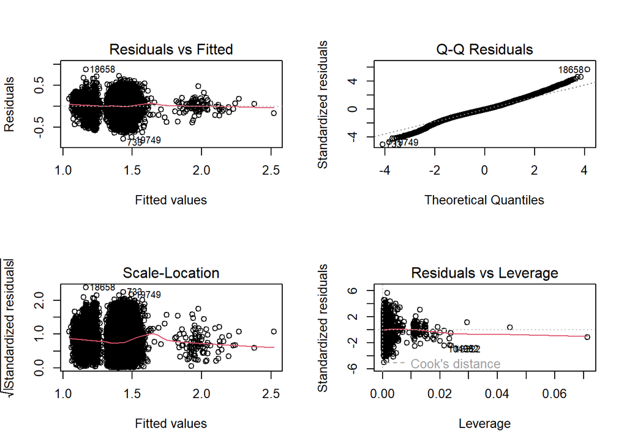

```r
par(mfrow=c(2,2))
plot(eme_lm.full.014)
```

1. **Residuals vs Fitted plot**: same situation of the previous models, here we can clearly see three distinct clusters.
2. **Q-Q Residuals plot**: is the best situation that we ever see in this analysis, later we have a closer and much more detailed look.
3. **Scaled-Location / Spread-Location plot**: homoscedasticity is not verified since we do not have constant variance of the residuals, in fact we can see a big cluster on the left and small groups of observation spreaded in the rest of the plot.
4. **Residuals VS Leverage plot**: we can’t see any hogh leverage points.

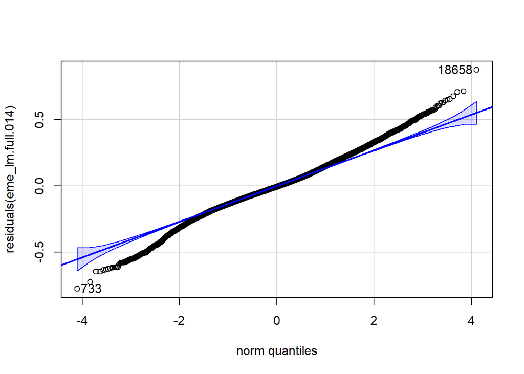

```
## [1] 18658   733
```

```r
qqPlot(residuals(eme_lm.full.014))
```

In this case the two tails appear to be more homogeneous and better respect the previous models and even the previous analysis, however the final conclusion is the same, we do not have normal distribution of residuals as we can see by the qqPlot.

```r
eme_lm.full.014.upd <- update(eme_lm.full, . ~ . + log(inc_resp_min_qy) - ladders_assigned - day_type)
summary(eme_lm.full.014.upd)
```

```
##
## Call:
## lm(formula = emergency_min_qy ~ inc_borough + cong_dist + al_source_desc +
##     al_index_desc + highest_al_level + inc_class_group + inc_resp_min_qy +
##     engines_assigned + others_units_assigned + working_hour +
##     time_of_day + tua_is_one + log(inc_resp_min_qy), data = fire_data_clean.train)
##
## Residuals:
##     Min      1Q  Median      3Q     Max
## -119.86   -8.60   -3.07    3.91  427.91
##
## Coefficients:
##                                Estimate Std. Error t value Pr(>|t|)
## (Intercept)                    -2.34477    1.66475  -1.408 0.159002
## inc_boroughBrooklyn            -5.69282    0.70968  -8.022 1.09e-15 ***
## inc_boroughManhattan           -0.82808    0.61337  -1.350 0.177013
## inc_boroughQueens              -3.14202    0.65882  -4.769 1.86e-06 ***
## inc_boroughStaten Island       -4.38531    1.14631  -3.826 0.000131 ***
## cong_dist5                      0.78360    0.91331   0.858 0.390910
## cong_dist6                      2.74455    0.95772   2.866 0.004164 **
## cong_dist7                      1.28079    0.98346   1.302 0.192814
## cong_dist8                      2.35115    1.08404   2.169 0.030101 *
## cong_dist9                      1.27654    1.10141   1.159 0.246464
## cong_dist10                     1.54357    1.07729   1.433 0.151921
## cong_dist11                     0.65841    1.29103   0.510 0.610064
## cong_dist12                     2.32910    1.14579   2.033 0.042089 *
## cong_dist13                     4.67531    1.09767   4.259 2.06e-05 ***
## cong_dist14                     2.66171    1.01545   2.621 0.008767 **
## cong_dist15                     3.25812    1.10437   2.950 0.003179 **
## cong_dist16                     2.13732    1.53832   1.389 0.164728
## al_source_descEMS               5.13717    0.72262   7.109 1.20e-12 ***
## al_source_descEMS-911           6.23795    0.72896   8.557  < 2e-16 ***
## al_source_descOthers            6.81971    0.77533   8.796  < 2e-16 ***
## al_source_descPHONE             4.33414    0.33743  12.845  < 2e-16 ***
## al_index_descInitial Alarm     16.06366    0.45296  35.464  < 2e-16 ***
## al_index_descOthers            64.10497    4.93097  13.000  < 2e-16 ***
## highest_al_levelNonFirst Alarm 61.31900    5.00046  12.263  < 2e-16 ***
## inc_class_groupM_MFAs          -1.76332    1.55868  -1.131 0.257943
## inc_class_groupNonM_E          -6.81116    0.66220 -10.286  < 2e-16 ***
## inc_class_groupNonM_MFAs       -2.66619    0.98027  -2.720 0.006536 **
## inc_class_groupNonS_F           2.54275    1.03211   2.464 0.013761 *
## inc_class_groupS_F             -5.57534    0.84763  -6.578 4.88e-11 ***
## inc_resp_min_qy                -0.01081    0.09224  -0.117 0.906670
## engines_assigned                1.65009    0.16040  10.287  < 2e-16 ***
## others_units_assigned           4.41661    0.16837  26.231  < 2e-16 ***
## working_hourTRUE               -0.73679    0.62533  -1.178 0.238712
## time_of_dayEvening             -2.21734    0.68372  -3.243 0.001184 **
## time_of_dayMorning              0.54524    0.27409   1.989 0.046680 *
## time_of_dayNight               -1.54462    0.70320  -2.197 0.028061 *
## tua_is_oneTRUE                  0.95304    0.37471   2.543 0.010984 *
## log(inc_resp_min_qy)            1.06086    0.63372   1.674 0.094138 .
## ---
## Signif. codes:  0 '***' 0.001 '**' 0.01 '*' 0.05 '.' 0.1 ' ' 1
##
## Residual standard error: 16.17 on 24542 degrees of freedom
## Multiple R-squared:  0.3353, Adjusted R-squared:  0.3343
## F-statistic: 334.5 on 37 and 24542 DF,  p-value: < 2.2e-16
```

By logarithm scaling the `inc_resp_min_qy` and removing non significant predictors we do not achive again great results.

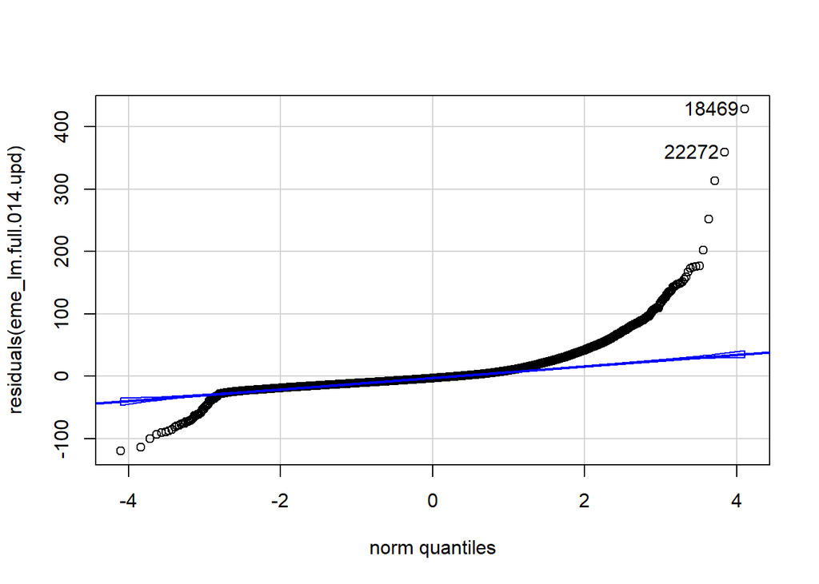

```
## [1] 18469 22272
```

```r
qqPlot(residuals(eme_lm.full.014.upd))
```

The situation on the qqPlot is the same.

### 2.2.2 Logarithm

Trying the **logarithm scale** of the response.

```r
eme_lm.full.log <- update(eme_lm.full, log(emergency_min_qy) ~ . - cong_dist - highest_al_level - inc_class_group)
summary(eme_lm.full.log)
```

```
##
## Call:
## lm(formula = log(emergency_min_qy) ~ inc_borough + al_source_desc +
##     al_index_desc + inc_resp_min_qy + engines_assigned + ladders_assigned +
##     others_units_assigned + day_type + working_hour + time_of_day +
##     tua_is_one, data = fire_data_clean.train)
##
## Residuals:
##     Min      1Q  Median      3Q     Max
## -5.5181 -0.4329  0.0087  0.4864  4.0532
##
## Coefficients:
##                              Estimate Std. Error t value Pr(>|t|)
## (Intercept)                 1.0154518  0.0450415  22.545  < 2e-16 ***
## inc_boroughBrooklyn        -0.3818921  0.0147480 -25.895  < 2e-16 ***
## inc_boroughManhattan       -0.0463825  0.0154286  -3.006  0.00265 **
## inc_boroughQueens          -0.2611600  0.0160973 -16.224  < 2e-16 ***
## inc_boroughStaten Island   -0.4363583  0.0256555 -17.008  < 2e-16 ***
## al_source_descEMS           0.6004061  0.0235061  25.543  < 2e-16 ***
## al_source_descEMS-911       0.6013046  0.0247585  24.287  < 2e-16 ***
## al_source_descOthers        0.3814683  0.0368387  10.355  < 2e-16 ***
## al_source_descPHONE         0.2784395  0.0168672  16.508  < 2e-16 ***
## al_index_descInitial Alarm  1.5275916  0.0178366  85.644  < 2e-16 ***
## al_index_descOthers         3.0478337  0.1038518  29.348  < 2e-16 ***
## inc_resp_min_qy            -0.0101317  0.0019978  -5.072 3.98e-07 ***
## engines_assigned            0.0516199  0.0082553   6.253 4.09e-10 ***
## ladders_assigned            0.0318025  0.0131931   2.411  0.01594 *
## others_units_assigned       0.0627180  0.0085469   7.338 2.23e-13 ***
## day_typeWeekend            -0.0006583  0.0115189  -0.057  0.95442
## working_hourTRUE           -0.0860137  0.0309642  -2.778  0.00548 **
## time_of_dayEvening         -0.1661495  0.0338647  -4.906 9.34e-07 ***
## time_of_dayMorning          0.0231035  0.0135745   1.702  0.08877 .
## time_of_dayNight           -0.1625713  0.0348577  -4.664 3.12e-06 ***
## tua_is_oneTRUE             -0.1175658  0.0187132  -6.283 3.39e-10 ***
## ---
## Signif. codes:  0 '***' 0.001 '**' 0.01 '*' 0.05 '.' 0.1 ' ' 1
##
## Residual standard error: 0.8012 on 24559 degrees of freedom
## Multiple R-squared:  0.2931, Adjusted R-squared:  0.2925
## F-statistic: 509.1 on 20 and 24559 DF,  p-value: < 2.2e-16
```

Remember again that we can’t compare the $R^2$ between the former and the latter model since the response is not on the same scale.

View the residuals.

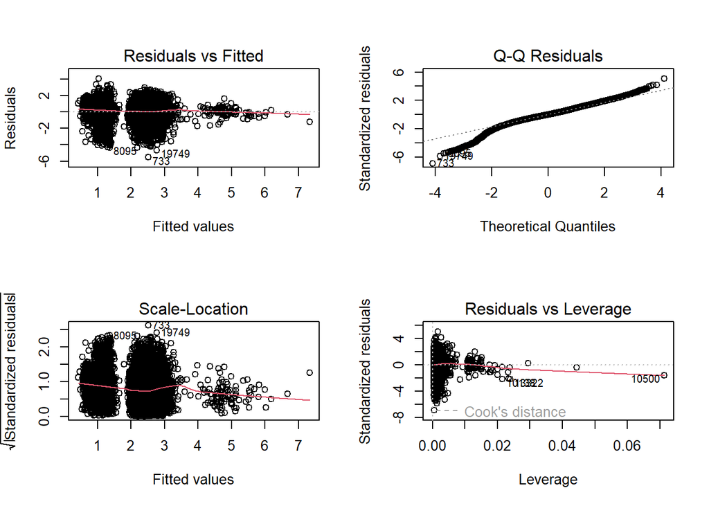

```r
par(mfrow=c(2,2))
plot(eme_lm.full.log)
```

1. The **Residuals VS Fitted** seems pretty good since the red line follows reasonably well the 0 horizontal dotted line, indicating our residuals have a linear relation with the fitted values, however they are not randomly spreaded since we can clearly see the presence of three clusters.
2. The **Q-Q Plots** again tells us that we are not in a situation of normally distributed residuals since we have the two tails that go outside the 95% confidence interval.
3. In the **Scale - Location Plots** homoscedasticity is not particularly satisfied since we have two main clusters and we have a decreasing trend.
4. In the **Residuals VS Leverage Plots** we can see that there are not any high leverage points that we have to process and investigate.

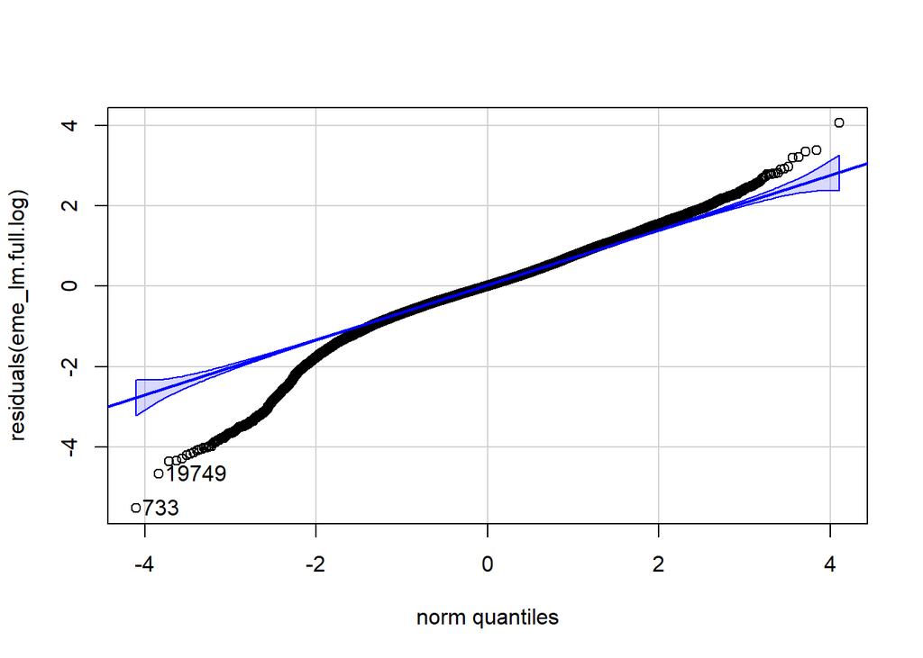

```
## [1]   733 19749
```

```r
qqPlot(residuals(eme_lm.full.log))
```

Here the right tail is less far from the 95% confidence interval with respect to the previous model, but on the other hand the left tail is heavily skewed to the bottom of the interval. Indicating that again we do not reach the normal distribution of the residual.

In conclusion we end up in a situation where the linearity assumptions are not met thus we can’t use a regression model to perform prediction even with the logarithm transformation of the response. It is very likely that powerful methods should be taken into account for this analysis with a deeper study of the relationship between predictors.

Moreover we think also that a deeper consideration of the outliers should be taken into account since are those observations that bring with them many informations

Please go to the **Part 3 - Binary Classification** to continue the analysis.